title: “Rapport d’analyse – Consommation alimentaire par zone”

author: “RIRADJIM NGARMOUNDOU Trésor”

institute: “École Nationale de la Statistique et de l’Analyse Économique de Dakar”

date: “15 May 2025”

# Analyse des tests statistiques

## Visualisation avec boxplot

Le diagramme en boîte (boxplot) permet une première exploration visuelle des différences entre les zones. On observe que la médiane de la consommation alimentaire est plus élevée en zone urbaine qu’en zone rurale. De plus, la dispersion semble plus importante en zone rurale, avec quelques valeurs extrêmes visibles. Cela suggère des différences de structure dans les distributions de consommation.

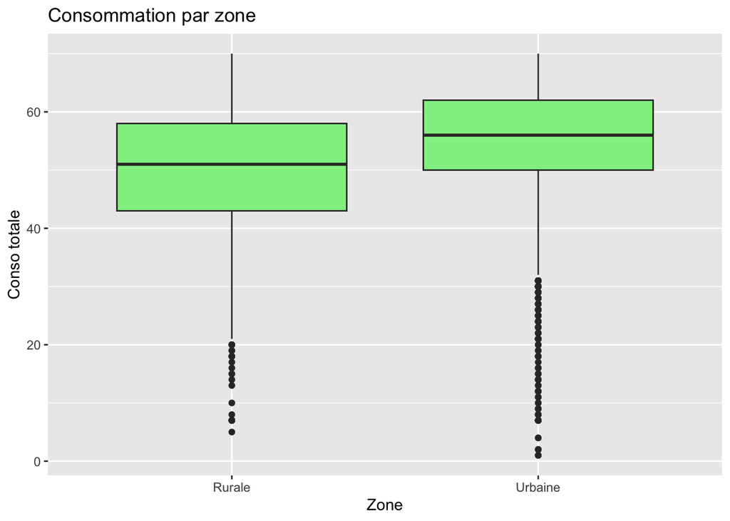

```r
ggplot(df, aes(zone, conso_total)) +
  geom_boxplot(fill = 'lightgreen') +
  labs(title = 'Consommation par zone', x = 'Zone', y = 'Conso totale')
```

## Test de Shapiro-Wilk

Ce test permet de vérifier la normalité des distributions dans chaque groupe. Les p-valeurs obtenues étant inférieures à 0,05, on rejette l’hypothèse de normalité dans les deux zones. Cela justifie le recours à des tests non paramétriques par la suite.

**Résultat :**

```r
shapiro.test(df$conso_total[df$zone == "Urbaine"])
```

```
##
##  Shapiro-Wilk normality test
##
## data:  df$conso_total[df$zone == "Urbaine"]
## W = 0.89772, p-value < 2.2e-16
```

```r
shapiro.test(df$conso_total[df$zone == "Rurale"])
```

```
##
##  Shapiro-Wilk normality test
##
## data:  df$conso_total[df$zone == "Rurale"]
## W = 0.97961, p-value < 2.2e-16
```

## Test de Levene

Ce test évalue l’homogénéité des variances. Le résultat montre une différence significative entre les variances des deux groupes (zones), indiquant une hétéroscédasticité. Cela confirme que les conditions d’un test paramétrique comme l’ANOVA classique ne sont pas réunies.

**Résultat :**

```r
leveneTest(conso_total ~ zone, data = df)
```

```
## Levene's Test for Homogeneity of Variance (center = median)
##         Df F value    Pr(>F)
## group    1  30.547 3.373e-08 ***
##       7135
## ---
## Signif. codes:  0 '***' 0.001 '**' 0.01 '*' 0.05 '.' 0.1 ' ' 1
```

## Test de Wilcoxon (Mann-Whitney)

Test non paramétrique qui compare les distributions. Il révèle une différence significative entre les zones urbaine et rurale. Cela suggère une disparité dans les niveaux de consommation alimentaire totale entre ces zones.

**Résultat :**

```r
wilcox.test(conso_total ~ zone, data = df)
```

```
##
##  Wilcoxon rank sum test with continuity correction
##
## data:  conso_total by zone
## W = 4638353, p-value < 2.2e-16
## alternative hypothesis: true location shift is not equal to 0
```

## Taille de l’effet (Cohen’s d)

La taille de l’effet est faible, indiquant que même si la différence est statistiquement significative, son ampleur reste modérée. Cela peut s’expliquer par une forte variabilité intra-groupe.

**Résultat :**

```r
cohens_d(df, conso_total ~ zone)
```

```
## # A tibble: 1 × 7
##   .y.         group1 group2  effsize    n1    n2 magnitude
## * <chr>       <chr>  <chr>     <dbl> <int> <int> <ord>
## 1 conso_total Rurale Urbaine  -0.405  3212  3925 small
```

## Test de Kolmogorov-Smirnov (KS)

Ce test compare les distributions empiriques des deux groupes. Le résultat est significatif, ce qui confirme que les distributions sont différentes entre zones.

**Résultat :**

```r
ks.test(df$conso_total[df$zone=='Urbaine'], df$conso_total[df$zone=='Rurale'])
```

```
##
##  Asymptotic two-sample Kolmogorov-Smirnov test
##
## data:  df$conso_total[df$zone == "Urbaine"] and df$conso_total[df$zone == "Rurale"]
## D = 0.22421, p-value < 2.2e-16
## alternative hypothesis: two-sided
```

## Test d’Anderson-Darling

Ce test affine la comparaison des distributions. Le résultat corrobore celui du test KS, renforçant l’idée d’une différence de forme entre les distributions urbaines et rurales.

**Résultat :**

```r
ad.test(conso_total ~ zone, data = df)
```

```
##
##
##  Anderson-Darling k-sample test.
##
## Number of samples:  2
## Sample sizes:  3212, 3925
## Number of ties: 7069
##
## Mean of  Anderson-Darling  Criterion: 1
## Standard deviation of  Anderson-Darling  Criterion: 0.7612
##
## T.AD = ( Anderson-Darling  Criterion - mean)/sigma
##
## Null Hypothesis: All samples come from a common population.
##
##                AD   T.AD  asympt. P-value
## version 1: 187.51 245.02      3.1079e-103
## version 2: 198.00 259.36      7.2728e-109
```

## Test de permutation

**Résultat :**

```r
obs <- max(abs(
  ecdf(df$conso_total[df$zone=='Urbaine'])(df$conso_total[df$zone=='Rurale']) -
  ecdf(df$conso_total[df$zone=='Rurale'])(df$conso_total[df$zone=='Urbaine'])
))
perm <- replicate(2000, {
  z <- sample(df$zone)
  max(abs(
    ecdf(df$conso_total[z=='Urbaine'])(df$conso_total[z=='Rurale']) -
    ecdf(df$conso_total[z=='Rurale'])(df$conso_total[z=='Urbaine'])
  ))
})
mean(perm >= obs)
```

```
## [1] 0.33
```

## Test du Chi-deux

**Résultat :**

```r
df2 <- df %>% mutate(cat = ntile(conso_total, 3))
tab <- table(df2$cat, df2$zone)
chisq.test(tab)
```

```
##
##  Pearson's Chi-squared test
##
## data:  tab
## X-squared = 374.21, df = 2, p-value < 2.2e-16
```

## ANOVA (analyse de la variance)

Bien que les conditions ne soient pas parfaitement remplies (non-normalité, variances inégales), l’ANOVA est réalisée à titre indicatif. Les résultats montrent une différence significative mais avec un faible eta², ce qui indique une variance expliquée limitée par le facteur “zone”.

**Résultat :**

```r
aov_res <- aov(conso_total ~ zone, data = df)
summary(aov_res)
```

```
##               Df Sum Sq Mean Sq F value Pr(>F)
## zone           1  34622   34622   289.7 <2e-16 ***
## Residuals   7135 852756     120
## ---
## Signif. codes:  0 '***' 0.001 '**' 0.01 '*' 0.05 '.' 0.1 ' ' 1
```

```r
eta_squared(aov_res)
```

```
##       zone
## 0.03901582
```

# Conclusion

- Les distributions de consommation diffèrent significativement entre zones.
- La zone géographique influence la consommation, mais l’effet reste modéré.
- L’analyse multivariée future pourrait aider à mieux comprendre ces différences en tenant compte d’autres variables explicatives.